# Notebook

### Web Information Retrieval and Data Mining - Assignment 3

```
Student: Jacobs, Mariska (1019990)
```

#### Answer 1.1, Baseline (4p)

- Dense network, at least 3 layers, shaped like a pyramid
  - Last layer: 10 nodes, sigmoid.
  - Loss: categorical cross-entropy. Metric: accuracy
- No preprocessing, regularization. Get at least 70% accuracy.
- Explain design decisions. Discuss performance.
  - Does it overfit (large/growing gap between loss and val_loss)?

```
(length: 0)

Max val score: 78.62%
```

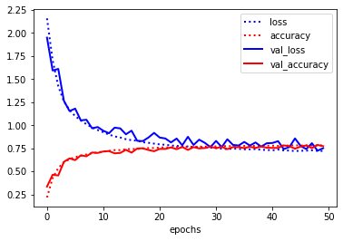

```
Model: "sequential_11"
_________________________________________________________________
Layer (type)                 Output Shape              Param #
=================================================================
reshape_10 (Reshape)         (None, 3072)              0
_________________________________________________________________
dense_32 (Dense)             (None, 270)               829710
_________________________________________________________________
dense_33 (Dense)             (None, 90)                24390
_________________________________________________________________
dense_34 (Dense)             (None, 30)                2730
_________________________________________________________________
dense_35 (Dense)             (None, 10)                310
=================================================================
Total params: 857,140
Trainable params: 857,140
Non-trainable params: 0
_________________________________________________________________
None
def build_model_1_1():
    model_1_1 = models.Sequential()
    model_1_1.add(layers.Reshape((3072,), input_shape=(32,32,3)))
    model_1_1.add(layers.Dense(270, activation='relu'))
    model_1_1.add(layers.Dense(90, activation='relu'))
    model_1_1.add(layers.Dense(30, activation='sigmoid'))
    model_1_1.add(layers.Dense(10, activation='sigmoid'))
    model_1_1.compile(optimizer='rmsprop',
              loss='categorical_crossentropy',
              metrics=['accuracy'])
    return model_1_1
```

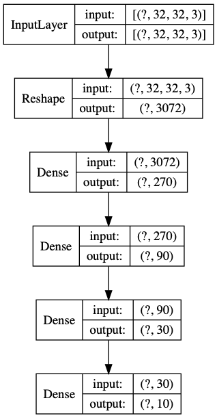

#### Answer 1.2, Preprocess (2p)

- Convert images to greyscale, other preprocessing optional.
  - Input shape should be (32,32,1)
- Explain design decisions. Is it better? Why (not)?
  - Color information is likely not so useful for classification. Greyscale makes the network smaller, less parameters to learn, less likely to overfit.

```
(length: 0)

Max val score: 79.22%
```

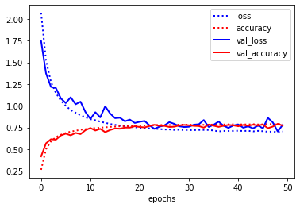

```
Model: "sequential_10"
_________________________________________________________________
Layer (type)                 Output Shape              Param #
=================================================================
reshape_9 (Reshape)          (None, 1024)              0
_________________________________________________________________
dense_28 (Dense)             (None, 270)               276750
_________________________________________________________________
dense_29 (Dense)             (None, 90)                24390
_________________________________________________________________
dense_30 (Dense)             (None, 30)                2730
_________________________________________________________________
dense_31 (Dense)             (None, 10)                310
=================================================================
Total params: 304,180
Trainable params: 304,180
Non-trainable params: 0
_________________________________________________________________
None
def build_model_1_2():
    model_1_2 = models.Sequential()
    model_1_2.add(layers.Reshape((1024,), input_shape=(32,32,1)))
    model_1_2.add(layers.Dense(270, activation='relu'))
    model_1_2.add(layers.Dense(90, activation='relu'))
    model_1_2.add(layers.Dense(30, activation='sigmoid'))
    model_1_2.add(layers.Dense(10, activation='sigmoid'))
    model_1_2.compile(optimizer='rmsprop',
              loss='categorical_crossentropy',
              metrics=['accuracy'])
    return model_1_2
```

#### Answer 1.3, Tune (4p)

- Regularize the model. What works best?
  - Should consider batch normalization, dropout, l1/l2 regularization (or Nesterov)
- Tune other hyperparameters (e.g. learning rate, batch size,...) as you see fit.
  - At least consider tuning learning rate, ideally also momentum, decay, other optimizers
- Explain your findings and final design decisions. Discuss the results.
  - Should be better, at least it shouldn't overfit

```
(length: 0)

Max val score: 80.38%
```

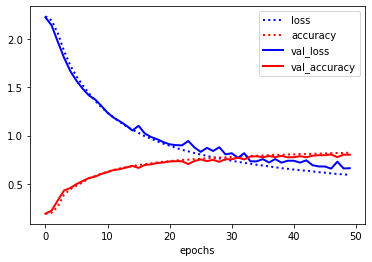

```
def build_model_1_3():
    model_1_3 = models.Sequential()
    model_1_3.add(layers.Reshape((1024,), input_shape=(32,32,1)))
    model_1_3.add(layers.Dense(270, activation='relu',
                               #kernel_regularizer=regularizers.l2(0.00005),
                                #activity_regularizer=regularizers.l2(0.00005),
                                   bias_regularizer=regularizers.l2(0.00005)
                              ))
    #model_1_3.add(layers.Dropout(0.1))
    model_1_3.add(layers.Dense(90, activation='relu',
                               #kernel_regularizer=regularizers.l2(0.00005),
                                #activity_regularizer=regularizers.l2(0.00005),
                                   bias_regularizer=regularizers.l2(0.00005)
                              ))
    #model_1_3.add(layers.Dropout(0.2))
    model_1_3.add(layers.Dense(30, activation='sigmoid',
                               #kernel_regularizer=regularizers.l2(0.01),
                                #activity_regularizer=regularizers.l1(0.01),
                                   #bias_regularizer=regularizers.l2(0.00005)
                              ))
    #model_1_3.add(layers.Dropout(0.5))
    model_1_3.add(layers.Dense(10, activation='sigmoid',
                               #kernel_regularizer=regularizers.l2(0.01),
                                #activity_regularizer=regularizers.l1(0.01),
                                   #bias_regularizer=regularizers.l2(0.00005)
                              ))
    model_1_3.compile(optimizer=optimizers.RMSprop(lr=0.0001),
              loss='categorical_crossentropy',
              metrics=['accuracy'])
    return model_1_3
```

#### Answer 2.1, ConvNet (7p)

- Build a sequential ConvNet, get at least 90% accuracy.
  - Conv2D layers, input shape (32,32,1)
  - Consider using blocks of Conv2D layers with maxpooling in between
  - Use zero-padding in Conv2D layers because the images are small
  - At least one dense hidden layer and dense output layer (sigmoid)
  - Consider adding batch normalization, dropout
  - Consider small dropout rates in beginning, larger dropout rates later in network
  - Consider other optimizers and tuning learning rate, momentum,...
- Explain what you did and why (800 chars). Is it working well?
  - Should be quite elaborate and sensible

[output not shown]

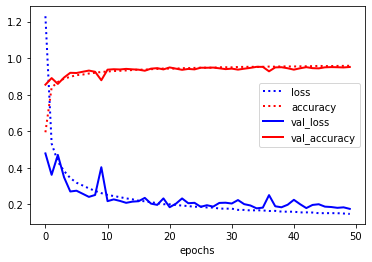

```
Model: "sequential_5"
_________________________________________________________________
Layer (type)                 Output Shape              Param #
=================================================================
conv2d_30 (Conv2D)           (None, 32, 32, 30)        300
_________________________________________________________________
conv2d_31 (Conv2D)           (None, 32, 32, 30)        8130
_________________________________________________________________
max_pooling2d_15 (MaxPooling (None, 16, 16, 30)        0
_________________________________________________________________
batch_normalization_15 (Batc (None, 16, 16, 30)        120
_________________________________________________________________
dropout_15 (Dropout)         (None, 16, 16, 30)        0
_________________________________________________________________
conv2d_32 (Conv2D)           (None, 16, 16, 60)        16260
_________________________________________________________________
conv2d_33 (Conv2D)           (None, 16, 16, 60)        32460
_________________________________________________________________
max_pooling2d_16 (MaxPooling (None, 8, 8, 60)          0
_________________________________________________________________
batch_normalization_16 (Batc (None, 8, 8, 60)          240
_________________________________________________________________
dropout_16 (Dropout)         (None, 8, 8, 60)          0
_________________________________________________________________
conv2d_34 (Conv2D)           (None, 8, 8, 90)          48690
_________________________________________________________________
conv2d_35 (Conv2D)           (None, 8, 8, 90)          72990
_________________________________________________________________
max_pooling2d_17 (MaxPooling (None, 4, 4, 90)          0
_________________________________________________________________
batch_normalization_17 (Batc (None, 4, 4, 90)          360
_________________________________________________________________
dropout_17 (Dropout)         (None, 4, 4, 90)          0
_________________________________________________________________
flatten_5 (Flatten)          (None, 1440)              0
_________________________________________________________________
dense_5 (Dense)              (None, 10)                14410
=================================================================
Total params: 193,960
Trainable params: 193,600
```

[output cut: 11 more lines]

```
    model_2_1.add(layers.Conv2D(60, (3, 3), activation='relu', padding='same'))
    model_2_1.add(layers.MaxPooling2D((2, 2)))
    model_2_1.add(layers.BatchNormalization())
    model_2_1.add(layers.Dropout(0.4))
    model_2_1.add(layers.Conv2D(90, (3, 3), activation='relu',padding='same'))
    model_2_1.add(layers.Conv2D(90, (3, 3), activation='relu',padding='same'))
    model_2_1.add(layers.MaxPooling2D((2, 2)))
    model_2_1.add(layers.BatchNormalization())
    model_2_1.add(layers.Dropout(0.6))
    model_2_1.add(layers.Flatten())
    model_2_1.add(layers.Dense(10, activation='sigmoid'))
    model_2_1.compile(optimizer='rmsprop',
                  loss='categorical_crossentropy',
                  metrics=['accuracy'])
    return model_2_1
```

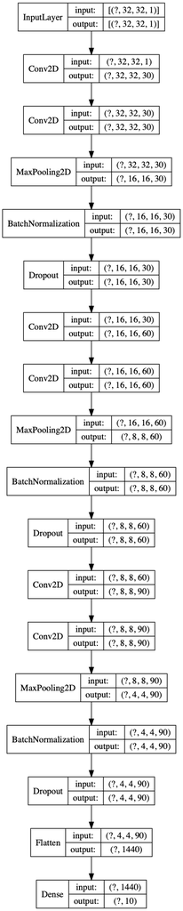

#### Answer 2.2, Data Augmentation (3p)

- Augment the preprocessed training data.
  - Use small variations (small shifts up-down, left-right) of flips becasue the images are small
  - Large shifts and rotations distort the image too much
- Explain what you did and why. Discuss the performance of the model.

```
(length: 0)

Max val score: 91.29%
```

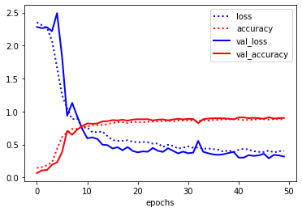

```
train_datagen = ImageDataGenerator(
    featurewise_center=False, samplewise_center=False,
    featurewise_std_normalization=False, samplewise_std_normalization=False,
    zca_whitening=False, zca_epsilon=1e-06, rotation_range=2, width_shift_range=0.0,
    height_shift_range=0.0, brightness_range=None, shear_range=0.0, zoom_range=0.0,
    channel_shift_range=0.0, fill_mode='wrap', cval=0.0, horizontal_flip=False,
    vertical_flip=False, rescale=False, preprocessing_function=None,
    data_format=None, validation_split=0.0, dtype=None
    )
```

#### Answer 3.1, Misclassifications (2p)

```
(length: 0)

Test score: [0.3166066292778028, 0.90573066]
```

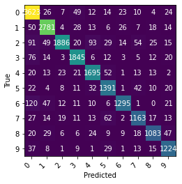

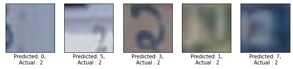

#### Answer 3.2, Activations (4p)

- Retrieve and visualize the activations for one example
- For every filter for different convolutional layers (at different depths in the network).
- Give an explanation. Is your model indeed learning something useful?
  - Should detect edges etc in first layers, higher-order object (e.g. interesting regions) in deeper layers.

```
(length: 0)
```

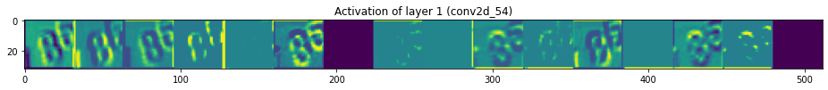

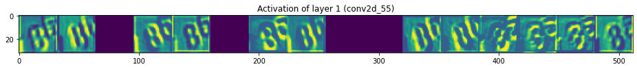

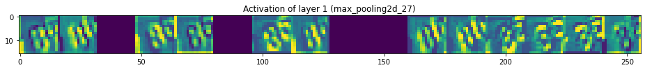

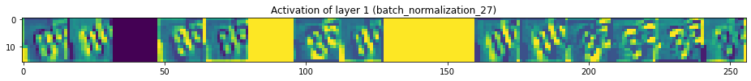

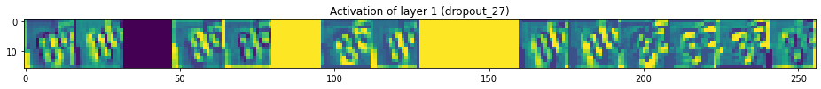

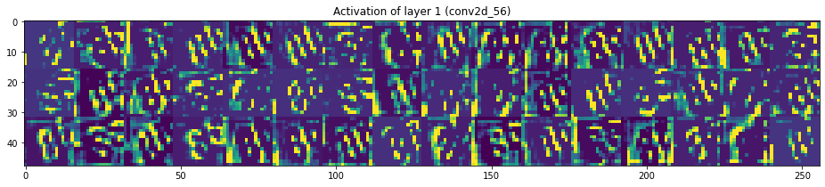

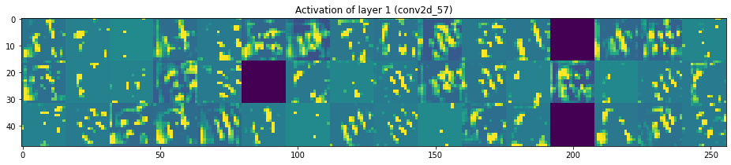

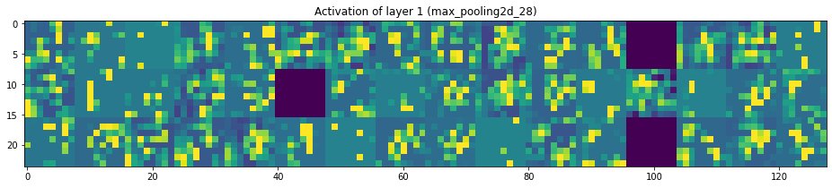

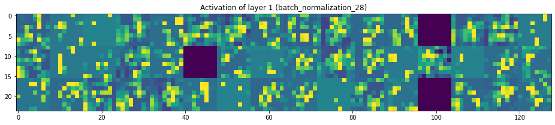

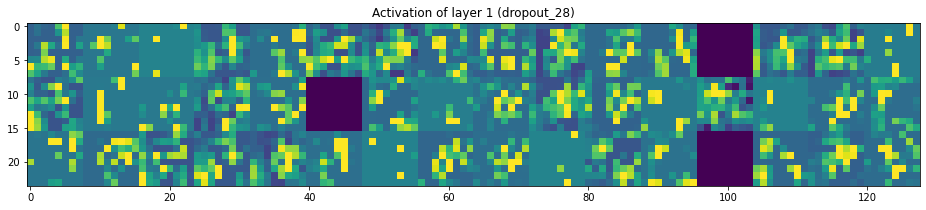

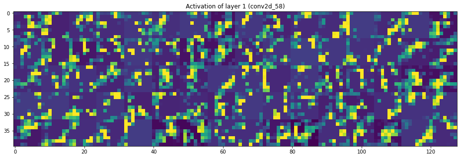

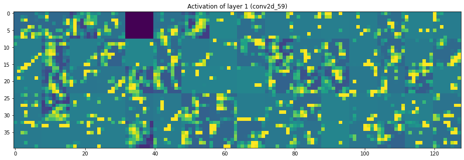

[3 more figures not shown]

#### Answer 3.3, Class activation map (4p)

- Show a class activation map for your last convolutional layer
- Superimpose the activation map over the image, or plot side by side
  - Should make sense, detect interesting regions to classify the number

[output not shown]

#### Answer 4.1, Fast feature extraction (5p)

- Import the VGG16 model, pretrained on ImageNet
- Freeze convolutional base, adds a dense layer
- Consider unfreezing the last few convolutional layers and evaluate whether that works better
  - Check if they do. It is very likely to help.
- Discuss the observed performance
  - Should get around 80% accuracy

```
(length: 0)

Max val score: 80.23%
```

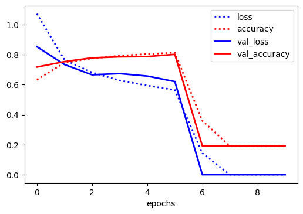

```
Model: "sequential_34"
_________________________________________________________________
Layer (type)                 Output Shape              Param #
=================================================================
vgg16 (Model)                (None, 1, 1, 512)         14714688
_________________________________________________________________
flatten_29 (Flatten)         (None, 512)               0
_________________________________________________________________
dense_72 (Dense)             (None, 300)               153900
_________________________________________________________________
dense_73 (Dense)             (None, 10)                3010
=================================================================
Total params: 14,871,598
Trainable params: 2,516,718
Non-trainable params: 12,354,880
_________________________________________________________________
None
def build_model_4_1():
  conv_base = VGG16(weights='imagenet', include_top=False, input_shape=(32, 32, 3))
  model_4_1 = models.Sequential()
  model_4_1.add(conv_base)
  model_4_1.add(layers.Flatten())
  model_4_1.add(layers.Dense(300, activation='relu'))
  model_4_1.add(layers.Dense(10, activation='sigmoid'))

  for layer in conv_base.layers:
    if layer.name == 'block5_conv3':
        layer.trainable = True
    if layer.name == 'block5_conv2':
        layer.trainable = True
    if layer.name == 'block5_conv1':
        layer.trainable = True
    else:
        layer.trainable = False

  model_4_1.compile(optimizer='rmsprop',
                  loss='categorical_crossentropy',
                  metrics=['accuracy'])
  return model_4_1
```

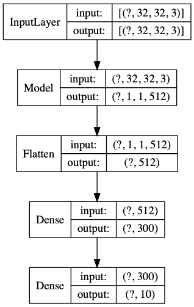

#### Answer 4.2, Embeddings (5p)

- Generate embeddings with the trained convolutional part of model_4_1 (without the dense layer)
- Embed the training and test data and store them to disk
- Build and evaluate a pipeline on the embedded data
  - Check if pipeline makes sense (e.g. use models that can handle many dimensions)
- Describe what you did and what you observed (max 800 chars).
  - Consider different models, preprocessing, tuning, etc.
  - Check performance (see original Submission.html) when in doubt. We did not run all the evaluations because it takes too long, and the output is ill-defined.

[output not shown]

```
Running time: 29.20 seconds
Last modified: May 26, 2020
scikit-learn version: 0.23.1
```